# *How to think like a computer scientist**

### Thunder Shiviah (github.com/ThunderShiviah)

##### *Disclaimer: I am not a computer scientist

# A few words about my background

# What this talk is about

- Using abstraction to manage complexity

## The hardest part of programming?

# Examples of complexity

- Major multi-million dollar projects without single working line of code

> Development of the website that would process online enrollments was done by Oracle Corporation and managed by the state of Oregon rather than an independent systems integrator.[11] The project was plagued by numerous management and technological issues, and though the website was supposed to begin processing enrollments on October 1, by mid-October, it was unable to process any enrollments.[12]

> As of mid-December 2013, the deadline for enrollment for coverage beginning January 1, the state had spent nearly \$160 million and the site still could not process online enrollments.[11] Governor John Kitzhaber informed Oregon residents that they should obtain a paper application and mail it in to obtain coverage.
- Radiation overdoses

> The Therac-25 was a radiation therapy machine produced by Atomic Energy of Canada Limited...

> **It was involved in at least six accidents between 1985 and 1987, in which patients were given massive overdoses of radiation. Because of concurrent programming errors, it sometimes gave its patients radiation doses that were thousands of times greater than normal, resulting in death or serious injury.**[2] These accidents highlighted the dangers of software control of safety-critical systems...

> **A commission concluded that the primary reason should be attributed to the bad software design and development practices, and not explicitly to several coding errors that were found. In particular, the software was designed so that it was realistically impossible to test it in a clean automated way.**[5]
- The list goes on and on

# How do we deal with complexity?

- Make it simple

**Elegance is power cloaked in simplicity** -- Robins and Beebe, *classic shell scripting*

# Algorithms

# A motivating problem

Find out if an element is in your data.

# Why we care

- Databases

# How is our data stored?

- Lots of possibilities: str, list, dict, tuple, set etc.

# Does our list contain a certain element?

```python
from random import randrange

def get_rand_list(n=10, upper_num=100):
    """Returns a  list of random numbers.

    Parameters
    ----------
    upper_num: int
        Sets the lower and upper bound for our random numbers
    n: int
        Sets the number of elements in our list.

    Returns
    -------
    list
    """
    return [randrange(upper_num) for x in range(n)] # returns a list of n random numbers

lst = get_rand_list()
print("list = ", lst)
```

```
list =  [79, 88, 55, 3, 2, 86, 34, 92, 53, 22]
```

```python
####### Exercise #######

def list_search(elem, lst):
    """ Returns True if elem is in lst and False otherwise."""
    return elem in lst

####### Tests #######

def list_search_pass_test():
    lst = [1,2,3,4]
    assert list_search(3, lst) == True


def list_search_fail_test():
    lst = [1,2,3,4]
    assert list_search(6, lst) == False


lst = get_rand_list()
elem = 71
print("Element is in list: {bool}".format(bool=list_search(elem, lst)))
```

```
Element is in list: False
```

### How can we check?

Start at the beginning and check every element (brute force).

```python
####### Exercise #######

def brute_force_search(elem, lst):
    """Returns True if elem is in lst and False otherwise."""

    bool_lst = [elem for num in lst if elem == num]
    return any(bool_lst) # returns false if bool_lst is empty


####### Tests #######

def brute_force_search_pass_test():
    lst = [1,2,3,4]
    assert brute_force_search(3, lst) == True


def brute_force_search_fail_test():
    lst = [1,2,3,4]
    assert brute_force_search(6, lst) == False


brute_force_search_pass_test()
brute_force_search_fail_test()
```

### Brute force method

- best case?
- worst case?
- what if the list is randomized? What's our average performance?
- Exercise using timeit
  - How does each case depend on the number of elements in the list?

| Prefix |  | 1000<sup>*m*</sup> | 10<sup>*n*</sup> | Decimal | English word |  | Since<sup>[nb 1]</sup> |  |
| --- | --- | --- | --- | --- | --- | --- | --- | --- |
| Name | Symbol |  |  |  | Short scale | Long scale |  |  |
|  |  | 1000<sup>0</sup> | 10<sup>0</sup> | 1 | one |  |  | – |
| deci | d | 1000<sup>−1/3</sup> | 10<sup>−1</sup> | 0.1 | tenth |  | 1960 (1795) |  |
| centi | c | 1000<sup>−2/3</sup> | 10<sup>−2</sup> | 0.01 | hundredth |  | 1960 (1795) |  |
| milli | m | 1000<sup>−1</sup> | 10<sup>−3</sup> | 0.001 | thousandth |  | 1960 (1795) |  |
| **micro** | μ | 1000<sup>−2</sup> | 10<sup>−6</sup> | 0.000001 | millionth |  | 1960 (1873) |  |
| nano | n | 1000<sup>−3</sup> | 10<sup>−9</sup> | 0.000000001 | billionth | thousand millionth | 1960 |  |

### Idea: what if our list was sorted?

- A smarter search algorithm?

### Binary Search

We consider three cases:

- If the target equals data[mid], then we have found the item we are looking for, and the search terminates successfully.
- If target < data[mid], then we recur on the first half of the sequence, that is, on the interval of indices from low to mid − 1.
- If target > data[mid], then we recur on the second half of the sequence, that is, on the interval of indices from mid + 1 to high. An unsuccessful search occurs if low > high, as the interval [low, high] is empty.

```python
def binary_search(item, alist):
    if len(alist) == 0:
        return False
    else:
        midpoint = len(alist)//2
        if alist[midpoint]==item:
            return True
        else:
            if item<alist[midpoint]:
                return binary_search(item, alist[:midpoint])
            else:
                return binary_search(item, alist[midpoint+1:])

testlist = [0, 1, 2, 8, 13, 17, 19, 32, 42,]
print(binary_search(3, testlist))
print(binary_search(13, testlist))
```

```
False
True
```

```python
#lst = sorted(get_rand_list())
lst = get_rand_list()
lst
```

```
[81, 30, 57, 24, 48, 23, 44, 76, 77, 36]
```

```python
binary_search(68, sorted(lst))
```

```
False
```

- Exercise using timeit
  - How does each case depend on the number of elements in the list?

# Divide and conquer

### problems with comparing binary search to brute force

- number of items in list
- hardware

# Big O notation

[figure not shown]

```python
from time import time

def func_timer(func, *params, verbose=False):
    """Takes in a function and some parameters to the function and returns the execution time"""
    start = time()
    func(*params)
    t = time() - start
    if verbose:
        print('function {func_name} took {time} seconds to complete given parameters'.format(
                func_name=func.__name__, time=t))
    return t

elem, n = 50, 10000
print(func_timer(brute_force_search, elem, get_rand_list(n), verbose=True))
print()
print(func_timer(list_search, elem, get_rand_list(n), verbose=True))
print()
print(func_timer(binary_search, elem, sorted(get_rand_list(n)), verbose=True))
```

```
function brute_force_search took 0.0005748271942138672 seconds to complete given parameters
0.0005748271942138672

function list_search took 1.3589859008789062e-05 seconds to complete given parameters
1.3589859008789062e-05

function binary_search took 1.1920928955078125e-05 seconds to complete given parameters
1.1920928955078125e-05
```

# In order to visualize the time complexity of our search algorithms, we'll generate a list of random lists sampled from length 1 to n.

# We will map our timing function and the search function to each list in our list and then plot the length of the list against its runtime.

```python
%matplotlib inline

from matplotlib import pyplot as plt



def sort_compare(max_size, num_samples, func):
    """Returns two lists corresponding to the lengths of random lists and the runtime
       execution of function func on those lists.
       """
    assert max_size > num_samples
    delta = max_size // num_samples # uses the floor function to get difference between each sample.
    lst_lengths = [delta*x for x in range(num_samples)]
    lst_of_rand_lsts = [get_rand_list(x) for x in lst_lengths]
    func_times_lst = [func_timer(func, 50, lst) for lst in lst_of_rand_lsts]

    return lst_lengths, func_times_lst
```

```python
def subplot_generator(lst_lengths, func_times_lst):
    plt.plot(lst_lengths, func_times_lst, 'bo')
    return


def sort_plotter(max_size, num_samples, *funcs):
    """Plots functions vs execution time.

    Details
    -------
    Creates plots of each function in *funcs wrt
    execution time by sampling num_samples lists of incremental
    length up to length max_size.

    Parameters
    ----------
    max_size: int
        The length of the final list sampled.
    num_samples: int
        The number of times to sample_the function.
    *functs: iterator
        An iterator containing the functions we wish to sample.

    Returns
    -------
    plots: matplotlib.pyplot
        Returns subplots with the length of the sampled
    list as the x-axis, and the average runtime of the
    function over the list using timeit.
    NOTE: timeit defaults to 1000 function calls.

    """

    print(type(funcs))
    # sort_compare(max_size, num_samples, func)

    return
```

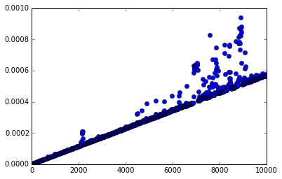

```python
lst_lengths, func_times_lst = sort_compare(10000, 1000, brute_force_search)
subplot_generator(lst_lengths, func_times_lst)
```

[figure not shown]

```python
lst_lengths, func_times_lst = set_compare(10000, 1000, set)
subplot_generator(lst_lengths, func_times_lst)
```

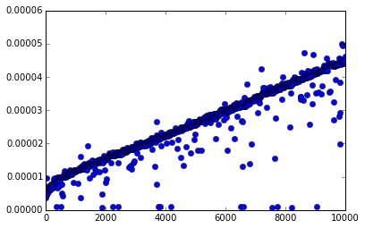

```python
lst_lengths, func_times_lst = sort_compare(10000, 1000, binary_search)
subplot_generator(lst_lengths, func_times_lst)
```

## Examples of other searches and sorting

- [Mike Bostock](http://bost.ocks.org/mike/algorithms/)